```r
library("IRdisplay")
```

# Machine Learning con Spark y R

# Fecha :08/04/2020

# Ronny Xavier Merchán Ponce

### Ingeniero Estadístico (ESPOL)

### Cientifico de Datos (Certificado JH)

### Certificaciones en (Sql , PowerBI,R ,Python)

### Investigador Independiente , Auto aprendizaje

# Experiencia

### Retail , Telecomunicaciones , actualmente sector Acuícola

# Allan Turing

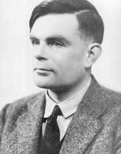

```r
display_png(file="allan turing.jpg",,width =300)
```

# Martin Minsky

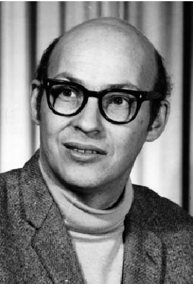

```r
display_png(file="martin minsky.png",width =200)
```

# Frank Rosenblatt

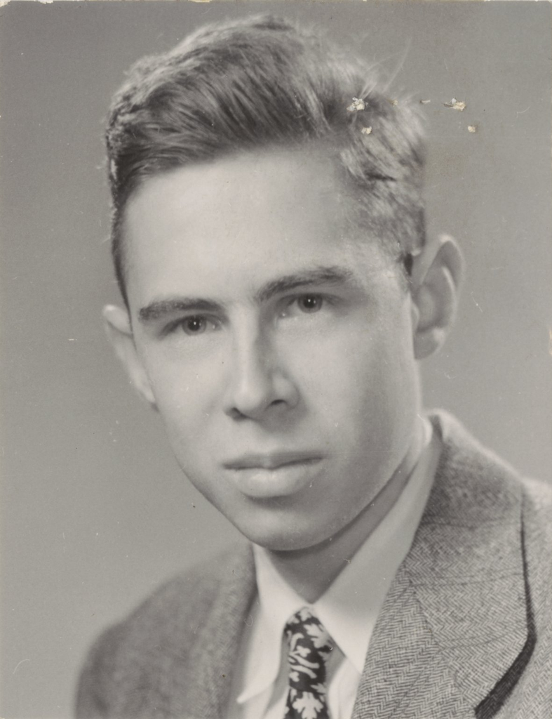

```r
display_png(file="Rosenblatt_21.jpg",width =200)
```

# John Quinlan

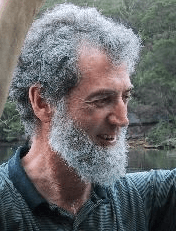

```r
display_png(file="J.-Ross-Quinlan.PNG",width =200)
```

# Leo Breiman

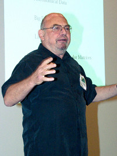

```r
display_png(file="Leo_Breiman.jpg",width =200)
```

# Geoffrey Hinton

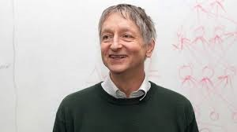

```r
display_png(file="Geofre.jpg")
```

# SKILL DATA SCIENTISTS

[figure not shown]

```r
display_png(file="graficolenguajes.JPG")
```

[figure not shown]

```r
display_png(file="sparkr.JPG")
```

# INTRODUCCIÓN A APACHE SPARK

Actualmente estamos viviendo la 4 Revolución Industrial , la cual se se basa en gran parte en el análisis de los datos , y cada día las industrias generan millones de datos o mas conocidos como Data Lakes . Tener una buena herramienta para el poder procesar los data lakes es una gran ventaja para los , Big Data Architect , Data Analitycs , Data Science , ya que pueden gestionar analizar y encontrar patrones de una manera mas eficaz que los metódos convencionales, ahí nace la necesida de tener herramientas como APACHE SPARK .

# Que es Spark (Gestor de datos) ?

Spark nacio en el 2009 desarrollado por Materi Zaharia cuando cursaba sus estudios Doctorales en Berkley ,posteriormente se torno como un lenguaje de codigo abierto bajo una licencia BSD (Berkeley Software Distribution) En 2013, el proyecto Spark fue donada a la empresa Apache Software Foundation ,y actualmente se ha convertido en un proyecto de alto nivel, todo esto para acelerar el proceso de cáculo computacionla Hadoop , es muy importante entender y mencionar que Apache Spark depende de Hadoop , ya que este lo utiliza para propósitos de almacenamiento. Observación Spark es un lenguaje de programación basado en Ada 83 ,que fue diseñado para sistemas de alta integridad a finales de los 80 (SPADE Ada Kernel) por por Bernard Carré y Trevor Jennings patrocinado por Ministerio de Defensa (MoD) británico.

## MATERI ZAHARIA EN UN EVENTO DE SPARK 2016

[figure not shown]

```r
display_png(file="zahariassw16.JPG",width = 600)
```

# Porque utilizar Spark ?

## Velocidad

Apache Spark es capaz de ejecutar hasta 100 veces más rápido aplicaciones ejecutadas en memoria y 10 veces más rápido cuando se ejecuta en HDD. Esto se debe principalmente a la reducción de número de operaciones de lectura / escritura en el disco y al nuevo almacenamiento de datos de procesamiento intermedio en memoria. Gracias a esta mejora en la velocidad, Spark ofrece una experimentación más veloz, mayor interactividad y mayor productividad para los analistas.

# Uso Amigable

Uno dos principales problemas que poseía Hadoop, es que requería de usuarios con niveles avanzados de MapReduce o programación avanzada en Java. Este inconveniente desaparece con la llegada de Spark, ya que gracias a la API nos permite programar en R, Python, Scala e incluso en Java. Además nos permite programar interactivamente en Python y Scala desde la consola directamente.

# Interactua con SQL

```r
Gracias al módulo Spark SQL se permite la consulta de datos
estructurados y semi-estructurados utilizando lenguaje SQL o gracias a la API, la
cual puede ser utilizada con Java, Scala, Python o R.
```

# Escalabilidad:

```r
Spark nos da la posibilidad de ir incrementando nuestro clúster a
medida que vamos necesitando más recursos.
```

# Algunos de los componentes de Spark

## Spark Core

Responasable de gestionar la funcionalidad de la programación de tareas

## Spark SQL

Modulo el cual permite la nueva idea de gestionar datos Schema RDD , tiene soporte para datos estructurados y semi estructurados , con este modulo se puede combinar el clásico query de SQL con la potencia de Spark .

## Spark Streaming

Permite gestionar análizar en vivo grande cantidades de datos o mejor llamados lotes , con esta ventaja se posee análisis conformen van ingresando los datos cabe recalcar que no existe latencia.

## MLib

Este es un framework de Machine Learning que tiene como finalidad hacer práctico el hecho de realizar modelos a grandes escalas , gracias a Spark basada en memoria distribuida se consiguen velocidades de procesamiento de los modelos superiores a cualquier software sea este Python , R , Matlab , etc.

## GraphX

Para procesamiento de imagenes y calculos gráficos en paralelo

# Paralalelismo Computacional

En 1958 Luigi Federico Menabrea habló sobre programación paralela y la necesidad de “branching” y “waiting”Porque hablamos de un paralelismo computacional , en torno a que además de tener un servidor de cualidades extraordinarias, tambien tendriamos que utilizar una maquina de caracteristicas altas , con Spark se puede utilizar un minimo de recurso computacional ,para procesar grandes cantidades de datos . Resuelve problemas que no se podrían realizar en una sola CPU Resuelve problemas que no se pueden resolver en un tiempo razonable Permite ejecutar problemas de un orden y complejidad mayor Permite ejecutar código de manera más rápida (aceleración) Permite ejecutar en general más problemas Obtención de resultados en menos tiempo Permite la ejecución de varias instrucciones en simultáneo Permite dividir una tarea en partes independientes

# Solución

Trabajar en paralelo con una red maquinas la cual distribuya nuestros datos en nodos de trabajo

# Opciones

## Trabajar de manera vectorial mediante lenguajes que ya son optimizados como C++ ,C

## Computing Cloud : Microsoft Azure , Google Cloud

## Otros Entornos : Scala , Kafka , Flink

# Hace 20 años procesar toda esta información era un problema por la limitación de las distribución de datos o la capacidad de procesamiento de los computadores u servidores.

# Modo de trabajo de Spark

# Arquitectura de Clúster de Spark

### Standalone

### Apache Mesos

### Hadoop YARN

# Resilient Distributed Datasets (RDDs)

```r
Los RDDS son cantidades de datos de solo lectura tras hacer acciones en datos originales , los RDDS permiten cagar grandes
cantidades de datos en memoria para un veloz procesamiento y ser dividen para ser tratados de una forma paralela
esto nos permite realizar operaciones sobre las grandes cantidades de datos de forma rápida, cabe recalcar que tolera fallos ,
gracias a la API de Spark nos permite la conexión a entornos y a sus repositorios como Hadoop , Cassandra , Kafka y asi la creación
de los RDDs
```

## Se puede generar estos ficheros de distintas maneras

Obtener datos de un fichero. Obtener datos almacenados en memoria. Obtener datos de otro RDD.

# Paralelismo en Spark y Distribución de Bases de Datos

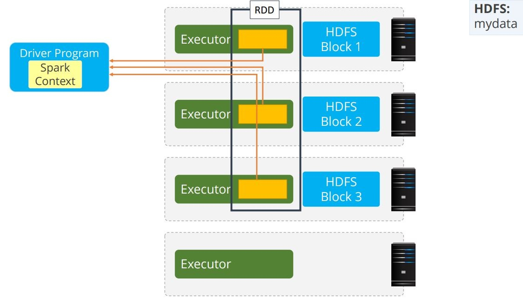

```r
display_png(file="paralelismo.JPG",width = 600)
```

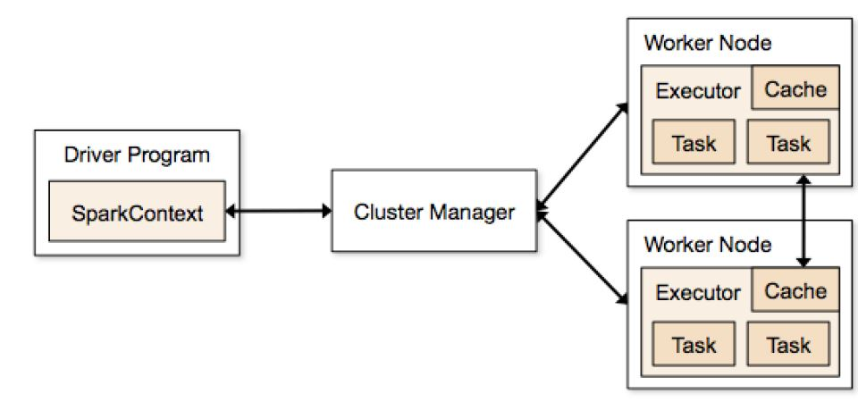

```r
display_png(file="spark5.JPG",width = 600)
```

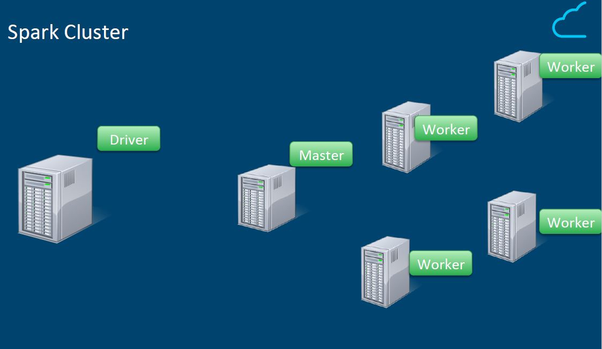

```r
display_png(file="cluste spark.JPG",width = 600)
```

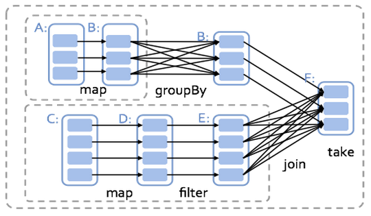

```r
display_png(file="reduce maps.png",width = 600)
```

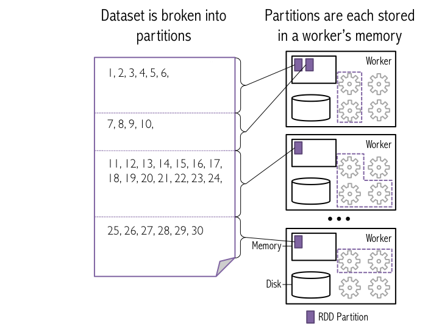

```r
display_png(file="partitions2.png",width = 600)
```

# Sparklyr

[figure not shown]

```r
display_png(file="sparklyr-illustration.png",width = 600)
```

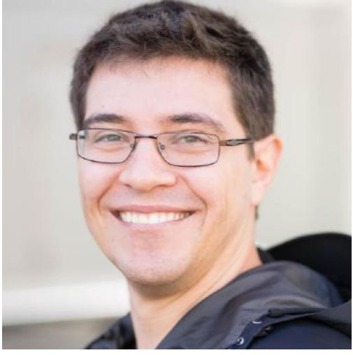

```r
display_png(file="xavierlau.jpg",width = 400)
```

Gracias a Javier Luraschi un Ingeniero de Software podemos utilizar Spark en un entorno de R studio , o JupiterNotebooks , este paquete nos permite interactuar los lagos de datos utilizando la optmización de Spark con la elegancia del codigo de R y algunos de sus pack principales como el famoso dplyr , así como utilizar las funciones de Machine Learning nativas de Spark entre otras ventajas .

[figure not shown]

```r
display_png(file="Spakfunci.JPG",width = 600)
```

[figure not shown]

```r
display_png(file="spark4.JPG",width = 600)
```

# https://spark.rstudio.com/guides/connections/

# CASO DE ESTUDIO DATATHON 2020

## https://www.kaggle.com/c/widsdatathon2020

base de hospitales training_v2